# predicting_ed_outcomes

### Clean the datasets

As seen below, the column names in data table and the variable and the variable_name column include spaces and parenthesis. All of which will cause issues with analysis later on.

```r
cat("Column names in `data` before cleaning:\n")
```

```
## Column names in `data` before cleaning:
```

```r
colnames(data)
```

```
##  [1] "Marital.status"
##  [2] "Application.mode"
##  [3] "Application.order"
##  [4] "Course"
##  [5] "Daytime.evening.attendance."
##  [6] "Previous.qualification"
##  [7] "Previous.qualification..grade."
##  [8] "Nacionality"
##  [9] "Mother.s.qualification"
## [10] "Father.s.qualification"
## [11] "Mother.s.occupation"
## [12] "Father.s.occupation"
## [13] "Admission.grade"
## [14] "Displaced"
## [15] "Educational.special.needs"
```

[output cut: 22 more lines]

```r
nrow(data)
```

```
## [1] 4424
```

```r
cat("\nColumn names in `variable_table` before cleaning:\n")
```

```
##
## Column names in `variable_table` before cleaning:
```

```r
colnames(variable_table)
```

```
## [1] "Variable Name"  "Role"           "Type"           "Demographic"
## [5] "Description"    "Units"          "Missing Values"
```

```r
cat("\nVariable names in `variable_table` before cleaning:\n")
```

```
##
## Variable names in `variable_table` before cleaning:
```

```r
print(variable_table$`Variable Name`)
```

```
##  [1] "Marital Status"
##  [2] "Application mode"
##  [3] "Application order"
##  [4] "Course"
##  [5] "Daytime/evening attendance"
##  [6] "Previous qualification"
##  [7] "Previous qualification (grade)"
##  [8] "Nacionality"
##  [9] "Mother's qualification"
## [10] "Father's qualification"
## [11] "Mother's occupation"
## [12] "Father's occupation"
## [13] "Admission grade"
## [14] "Displaced"
## [15] "Educational special needs"
```

[output cut: 22 more lines]

In order to remove these problematic characters, the following regex code removes them.

```r
clean_names <- function(names) {
  names %>%
    tolower() %>%
    gsub("[ .\\(\\)/'\\-]", "_", .) %>%
    gsub("_+", "_", .) %>%
    gsub("^_|_$", "", .) %>%
    trimws()
}

# Apply the cleaning function to `data` and `variable_table` names
colnames(data) <- clean_names(colnames(data))
colnames(variable_table) <- clean_names(colnames(variable_table))

# Print cleaned column names
cat("\nColumn names in `data` after cleaning:\n")
```

```
##
## Column names in `data` after cleaning:
```

```r
print(colnames(data))
```

```
##  [1] "marital_status"
##  [2] "application_mode"
##  [3] "application_order"
##  [4] "course"
##  [5] "daytime_evening_attendance"
##  [6] "previous_qualification"
##  [7] "previous_qualification_grade"
##  [8] "nacionality"
##  [9] "mother_s_qualification"
## [10] "father_s_qualification"
## [11] "mother_s_occupation"
## [12] "father_s_occupation"
## [13] "admission_grade"
## [14] "displaced"
## [15] "educational_special_needs"
```

[output cut: 22 more lines]

```r
cat("\nColumn names in `variable_table` after cleaning:\n")
```

```
##
## Column names in `variable_table` after cleaning:
```

```r
print(colnames(variable_table))
```

```
## [1] "variable_name"  "role"           "type"           "demographic"
## [5] "description"    "units"          "missing_values"
```

```r
variable_table$variable_name <- clean_names(variable_table$variable_name)
```

Now that the problematic characters have been removed, ensure all variable names are consistent:

```r
matching_variables <- intersect(colnames(data), variable_table$variable_name)
non_matching_in_data <- setdiff(colnames(data), variable_table$variable_name)
non_matching_in_variable_table <- setdiff(variable_table$variable_name, colnames(data))

# Display the matching and non-matching variables
cat("\nMatching Variables:\n")
```

```
##
## Matching Variables:
```

```r
print(matching_variables)
```

```
##  [1] "marital_status"
##  [2] "application_mode"
##  [3] "application_order"
##  [4] "course"
##  [5] "daytime_evening_attendance"
##  [6] "previous_qualification"
##  [7] "previous_qualification_grade"
##  [8] "nacionality"
##  [9] "mother_s_qualification"
## [10] "father_s_qualification"
## [11] "mother_s_occupation"
## [12] "father_s_occupation"
## [13] "admission_grade"
## [14] "displaced"
## [15] "educational_special_needs"
```

[output cut: 22 more lines]

The code above shows that all 37 variable names are now matching.

### Encode Target as Numeric

As seen in the table below, like the other variables in the dataset, Target is now encoded numerically:

```r
# Encode 'target' variable with a numeric representation
data$target <- ifelse(data$target == "Dropout", 1,
                      ifelse(data$target == "Enrolled", 2,
                             ifelse(data$target == "Graduate", 3, NA)))
sort(unique(data$target))
```

```
## [1] 1 2 3
```

The target variable is now numeric: - “Dropout” -> 1 - “Enrolled” -> 2 - “Graduate” -> 3

Next, the dataset is split to avoid overtraining and other validation challenges with model training.

## Split the dataset & Justify

```r
nrow(data)
```

```
## [1] 4424
```

```r
table(data$target)
```

```
##
##    1    2    3
## 1421  794 2209
```

A 20% holdout set is reserved before final testing, ensuring the dataset’s class distribution is maintained, sufficient representation for all three outcome classes are retained, and 80% of the data can be used for training and validation.

```r
set.seed(123)
trainindex <- createDataPartition(data$target, p = .8,
                                  list = FALSE,
                                  times = 1)
traindata <- data[trainindex,]
final_holdout_set  <- data[-trainindex,]

# For sanity, print NAs in traindata
total_nas_traindata <- sum(is.na(traindata))
cat("Total NAs in traindata:", total_nas_traindata, "\n")
```

```
## Total NAs in traindata: 0
```

```r
# Print NAs in final_holdout_data
total_nas_final_holdout_set <- sum(is.na(final_holdout_set))
cat("Total NAs in final_holdout_set data:", total_nas_final_holdout_set, "\n")
```

```
## Total NAs in final_holdout_set data: 0
```

From here on, this report will only work with the traindata set. This will prevent any patterns and observations about the holdoutset from informing the training of the learning models. In this way, the final holdout set will be an independent test of model effectriveness.

## Exploratory Data Analysis

Now that the data has been cleaned, some exploration can be done to better understand the students in the traindata by inspecting the variables that describe them. Any findings can contribute to the modeling done later.

```r
# See number of students in dataset
nrow(traindata)
```

```
## [1] 3540
```

```r
ncol(traindata)
```

```
## [1] 37
```

```r
unique(traindata$target)
```

```
## [1] 1 3 2
```

```r
table(traindata$target)
```

```
##
##    1    2    3
## 1125  647 1768
```

```r
head(traindata)
```

|  | marital_status | application_mode | application_order | course | daytime_evening_attendance | previous_qualification | previous_qualification_grade | nacionality | mother_s_qualification | father_s_qualification | mother_s_occupation | father_s_occupation | admission_grade | displaced | educational_special_needs | debtor | tuition_fees_up_to_date | gender | scholarship_holder | age_at_enrollment | international | curricular_units_1st_sem_credited | curricular_units_1st_sem_enrolled | curricular_units_1st_sem_evaluations | curricular_units_1st_sem_approved | curricular_units_1st_sem_grade | curricular_units_1st_sem_without_evaluations | curricular_units_2nd_sem_credited | curricular_units_2nd_sem_enrolled | … |
| --- | --- | --- | --- | --- | --- | --- | --- | --- | --- | --- | --- | --- | --- | --- | --- | --- | --- | --- | --- | --- | --- | --- | --- | --- | --- | --- | --- | --- | --- | --- |
| 1 | 1 | 17 | 5 | 171 | 1 | 1 | 122.0 | 1 | 19 | 12 | 5 | 9 | 127.3 | 1 | 0 | 0 | 1 | 1 | 0 | 20 | 0 | 0 | 0 | 0 | 0 | 0.00000 | 0 | 0 | 0 | … |
| 2 | 1 | 15 | 1 | 9254 | 1 | 1 | 160.0 | 1 | 1 | 3 | 3 | 3 | 142.5 | 1 | 0 | 0 | 0 | 1 | 0 | 19 | 0 | 0 | 6 | 6 | 6 | 14.00000 | 0 | 0 | 6 | … |
| 3 | 1 | 1 | 5 | 9070 | 1 | 1 | 122.0 | 1 | 37 | 37 | 9 | 9 | 124.8 | 1 | 0 | 0 | 0 | 1 | 0 | 19 | 0 | 0 | 6 | 0 | 0 | 0.00000 | 0 | 0 | 6 | … |
| 4 | 1 | 17 | 2 | 9773 | 1 | 1 | 122.0 | 1 | 38 | 37 | 5 | 3 | 119.6 | 1 | 0 | 0 | 1 | 0 | 0 | 20 | 0 | 0 | 6 | 8 | 6 | 13.42857 | 0 | 0 | 6 | … |
| 5 | 2 | 39 | 1 | 8014 | 0 | 1 | 100.0 | 1 | 37 | 38 | 9 | 9 | 141.5 | 0 | 0 | 0 | 1 | 0 | 0 | 45 | 0 | 0 | 6 | 9 | 5 | 12.33333 | 0 | 0 | 6 | … |
| 6 | 2 | 39 | 1 | 9991 | 0 | 19 | 133.1 | 1 | 37 | 37 | 9 | 7 | 114.8 | 0 | 0 | 1 | 1 | 1 | 0 | 50 | 0 | 0 | 5 | 10 | 5 | 11.85714 | 0 | 0 | 5 | … |

In order to have a functional and targeted exploration, the following section performs a linear regression to get an idea of what variables are predictive of dropout, enrolled, and graduated. Afterwards, these predictive variables will be explored more thoroughly.

### Linear Regression

To better understand the predictive variables in the dataset, this regression will visualize how certain variables might be predictive of target as a whole.

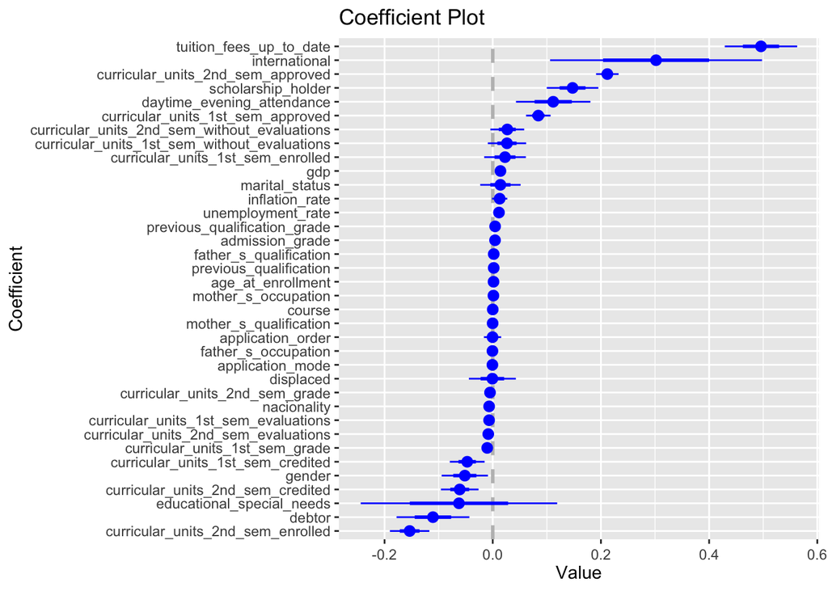

```r
# Extract variable names for the formula
variables_train <- colnames(traindata)

# Remove the 'target' variable from the list of predictors
variables_train <- variables_train[variables_train != "target"]

# Create the formula as a string
formula_string_train <- paste("target ~", paste(variables_train, collapse = " + "), - 1)

# Convert the string to a formula object
formula_train <- as.formula(formula_string_train)

# Perform linear regression
value1 <- lm(formula_train, data = traindata)

# Visualize the coefficients
regression_plot<-coefplot(value1, sort = 'magnitude', conf.int = TRUE)
regression_plot
```

The coefficient plot above provides insights into the variables’ relationships with the target outcomes and their relative strengths. It highlights variables with significant predictive power, as well as those with wide error margins crossing zero, suggesting limited or no effect.

### Key Regression Findings:

- **Strong Predictors (Positive Association):** Due to the positive coefficients, the plot suggests focusing on variables such as: `tuition_fees_up_to_date`, `international`, `curricular_units_2nd_sem_approved`, `scholarship_holder`, `daytime_evening_attendance`, and `curricular_units_1st_sem_approved` These range approximately from 0.1 to 0.5, indicating a positive contribution toward favorable outcomes like graduation or enrollment.

Conversely, certain factors show negative correlations with the target, as indicated by their negative coefficients. These include:`gender`, `curricular_units_1st_sem_credited`, `curricular_units_2nd_sem_credited`, `educational_special_needs`, `debtor`, and `curricular_units_2nd_sem_enrolled`. These insights suggest these variables are just as important, because they may be associated with lower values of target, such as dropout and enrolled.

Together, these findings provide a foundation for deeper exploration into how these variables influence the target outcomes and how they can be utilized effectively in predictive modeling.

## Investigate Predictive Variables

Based on the regression above, the following exploration targets variables identified as predictive.

```r
binary_vars <- c("tuition_fees_up_to_date", "gender", "scholarship_holder",
                 "debtor", "international", "educational_special_needs")
categorical_vars <- c("marital_status", "application_mode", "daytime_evening_attendance", "nacionality")
continuous_vars <- c("admission_grade", "curricular_units_1st_sem_grade", "gdp")
```

## Binary variables

Since all variables are encoded numerically, the following code will tell us what the binary values mean.

```r
variable_table %>%
  slice(c(14:19, 21)) %>%  # Select rows 14 to 19 and 21
  select(variable_name, description) %>%  # Select specific columns
  print()
```

```
## # A tibble: 7 × 2
##   variable_name             description
##   <chr>                     <chr>
## 1 displaced                 1 - yes 0 - no
## 2 educational_special_needs 1 - yes 0 - no
## 3 debtor                    1 - yes 0 - no
## 4 tuition_fees_up_to_date   1 - yes 0 - no
## 5 gender                    1 - male 0 - female
## 6 scholarship_holder        1 - yes 0 - no
## 7 international             1 - yes 0 - no
```

Now plot the students across these variables.

[figure not shown]

```r
# Plot distribution of binary data
binary_data <- traindata %>%
  select(all_of(binary_vars)) %>%
  pivot_longer(cols = everything(), names_to = "Variable", values_to = "Value") %>%
  count(Variable, Value)
# Map human-readable names for binary variable values
value_labels <- c("0" = "No/Not Applicable/Male", "1" = "Yes/Applicable/Female")
ggplot(binary_data, aes(x = Variable, y = n, fill = as.factor(Value))) +
  geom_bar(stat = "identity", position = "dodge", color = "black") +
  scale_fill_manual(
    values = c("0" = "steelblue", "1" = "lightcoral"),
    labels = value_labels
  ) +
  geom_text(
    aes(label = n),
    position = position_dodge(width = 0.9),
    vjust = -0.5,
    size = 3
  ) +
  labs(
    title = "Distribution of Binary Variables",
    x = "Variables",
    y = "Count",
    fill = "Value"
  ) +
  theme_minimal() +
  theme(
    axis.text.x = element_text(angle = 45, hjust = 1),
    plot.title = element_text(hjust = 0.5)
  )
```

```r
binary_target_table <- traindata %>%
  select(all_of(binary_vars), target) %>%
  pivot_longer(cols = -target, names_to = "Variable", values_to = "Value") %>%
  count(Variable, Value, target) %>%
  pivot_wider(
    names_from = target,
    values_from = n,
    values_fill = 0, # Fill missing combinations with 0
    names_prefix = "Target_"
  )
print(binary_target_table)
```

```
## # A tibble: 12 × 5
##    Variable                  Value Target_1 Target_2 Target_3
##    <chr>                     <int>    <int>    <int>    <int>
##  1 debtor                        0      887      578     1683
##  2 debtor                        1      238       69       85
##  3 educational_special_needs     0     1111      639     1750
##  4 educational_special_needs     1       14        8       18
##  5 gender                        0      556      397     1325
##  6 gender                        1      569      250      443
##  7 international                 0     1098      624     1727
##  8 international                 1       27       23       41
##  9 scholarship_holder            0     1017      538     1104
## 10 scholarship_holder            1      108      109      664
## 11 tuition_fees_up_to_date       0      364       35       22
## 12 tuition_fees_up_to_date       1      761      612     1746
```

The chart above reflects the regression above that these variables do have a high number of graduated students, which is typical with the National Center for Education Statistics reporting average 6 year graduation of college at 64% in 2020.

### Scholarship VS Dropout

Below, one can see the rate of scholarship holders dropping out (12%) is much lower than that of non_scholarship holders (38%).

```r
# Compare scholarship holder drop out vs non_scholarship holder dropout
scholarship_holder_rate <- binary_target_table %>%
  filter(Variable == "scholarship_holder", Value == 1) %>%
  summarize(
    total_scholarship_dropouts = sum(Target_1),
    total_scholarship_students = sum(Target_1 + Target_2 + Target_3),
    scholarship_dropout_rate = total_scholarship_dropouts / total_scholarship_students
  )
scholarship_holder_rate
```

| total_scholarship_dropouts | total_scholarship_students | scholarship_dropout_rate |
| --- | --- | --- |
| 108 | 881 | 0.122588 |

```r
# same as above for non_scholarship holders
non_scholarship_holder_rate <- binary_target_table %>%
  filter(Variable == "scholarship_holder", Value == 0) %>%
  summarize(
    total_non_scholarship_dropouts = sum(Target_1),
    total_non_scholarship_students = sum(Target_1 + Target_2 + Target_3),
    non_scholarship_dropout_rate = total_non_scholarship_dropouts / total_non_scholarship_students
  )
non_scholarship_holder_rate
```

| total_non_scholarship_dropouts | total_non_scholarship_students | non_scholarship_dropout_rate |
| --- | --- | --- |
| 1017 | 2659 | 0.3824746 |

This finding suggests financial support is a strong incentive to not dropout.

### Gender Vs Dropout

```r
gender_male_rate <- binary_target_table %>%
  filter(Variable == "gender", Value == 0) %>%
  summarize(
    total_male_dropouts = sum(Target_1),
    total_male_students = sum(Target_1 + Target_2 + Target_3),
    male_dropout_rate = total_male_dropouts / total_male_students
  )
gender_male_rate
```

[output not shown]

```r
gender_female_rate <- binary_target_table %>%
  filter(Variable == "gender", Value == 1) %>%
  summarize(
    total_female_dropouts = sum(Target_1),
    total_female_students = sum(Target_1 + Target_2 + Target_3),
    female_dropout_rate = total_female_dropouts / total_female_students
  )
gender_female_rate
```

[output not shown]

### Owing Fees VS Dropout

Almost all of students who owe tuition fees (87%) dropout. Shedding light again on the importance of financial support and reflecting the finding in the regression chart as the most predictive with a correlation coefficient of .5.

```r
owe_fees_drop_rate <- binary_target_table %>%
  filter(Variable == "tuition_fees_up_to_date", Value == 0) %>%
  summarize(
    total_owe_fee_dropouts = sum(Target_1),
    total_owe_fee_students = sum(Target_1 + Target_2 + Target_3),
    owe_fee_dropout_rate = total_owe_fee_dropouts / total_owe_fee_students
  )
owe_fees_drop_rate
```

| total_owe_fee_dropouts | total_owe_fee_students | owe_fee_dropout_rate |
| --- | --- | --- |
| 364 | 421 | 0.8646081 |

### International Students & Dropout

International students have a drop out rate of 30%, which is similar to the total dropout rate of teh data set ~32%.This is interesting when internation status was the second most predictive variable after tuition and fees up to date.

```r
international_rate <- binary_target_table %>%
  filter(Variable == "international", Value == 1) %>%
  summarize(
    total_international_dropouts = sum(Target_1),
    total_international_students = sum(Target_1 + Target_2 + Target_3),
    international_dropout_rate = total_international_dropouts / total_international_students
  )
international_rate
```

| total_international_dropouts | total_international_students | international_dropout_rate |
| --- | --- | --- |
| 27 | 91 | 0.2967033 |

```r
# Calculate overall dropout rate
overall_dropout_rate <- traindata %>%
  summarize(
    total_dropouts = sum(target == 1),
    total_students = n(),
    dropout_rate = total_dropouts / total_students
  )
overall_dropout_rate
```

| total_dropouts | total_students | dropout_rate |
| --- | --- | --- |
| 1125 | 3540 | 0.3177966 |

### Students with Special Needs & Dropout

Although there were not many students with special needs in the dataset, the the perseverence of these students, and possibly their support is clear when the dropout rate of 35% is not much higher than that of the dataset as a whole (~32%)

```r
educational_special_needs_rate <- binary_target_table %>%
  filter(Variable == "educational_special_needs", Value == 1) %>%
  summarize(
    total_special_needs_dropouts = sum(Target_1),
    total_special_needs_students = sum(Target_1 + Target_2 + Target_3),
    special_needs_dropout_rate = total_special_needs_dropouts / total_special_needs_students
  )
educational_special_needs_rate
```

| total_special_needs_dropouts | total_special_needs_students | special_needs_dropout_rate |
| --- | --- | --- |
| 14 | 40 | 0.35 |

## Exploring Continuous Variables (Academic Performance Variables)

```r
semester_variables <- variable_table %>%
  slice(22:33) %>%
  mutate(
    Semester = if_else(str_detect(variable_name, "1st_sem"), "1st Semester", "2nd Semester")
  )
print(semester_variables %>% select(variable_name, Semester))
```

```
## # A tibble: 12 × 2
##    variable_name                                Semester
##    <chr>                                        <chr>
##  1 curricular_units_1st_sem_credited            1st Semester
##  2 curricular_units_1st_sem_enrolled            1st Semester
##  3 curricular_units_1st_sem_evaluations         1st Semester
##  4 curricular_units_1st_sem_approved            1st Semester
##  5 curricular_units_1st_sem_grade               1st Semester
##  6 curricular_units_1st_sem_without_evaluations 1st Semester
##  7 curricular_units_2nd_sem_credited            2nd Semester
##  8 curricular_units_2nd_sem_enrolled            2nd Semester
##  9 curricular_units_2nd_sem_evaluations         2nd Semester
## 10 curricular_units_2nd_sem_approved            2nd Semester
## 11 curricular_units_2nd_sem_grade               2nd Semester
## 12 curricular_units_2nd_sem_without_evaluations 2nd Semester
```

As seen above the curricular unit variables give us 6 looks at how the students stand each semester. - The number of credits earned - The number of units enrolled in - The number of evaluations/ tests taken - The number of units they were approved to take - Their Grade avg - The number of units that didn’t have tests/evaluations (conceivably easier courses.)

### Identify trends

The following code groups the continuous variables by semester and summarize their statistics

```r
semester_summary <- traindata %>%
  select(all_of(semester_variables$variable_name)) %>%
  pivot_longer(everything(), names_to = "variable_name", values_to = "value") %>%
  left_join(semester_variables, by = "variable_name") %>%
  group_by(Semester, variable_name) %>%
  summarize(
    Mean = mean(value, na.rm = TRUE),
    Median = median(value, na.rm = TRUE),
    SD = sd(value, na.rm = TRUE),
    Min = min(value, na.rm = TRUE),
    Max = max(value, na.rm = TRUE),
    .groups = "drop"
  )
print(semester_summary)
```

```
## # A tibble: 12 × 7
##    Semester     variable_name                      Mean Median    SD   Min   Max
##    <chr>        <chr>                             <dbl>  <dbl> <dbl> <dbl> <dbl>
##  1 1st Semester curricular_units_1st_sem_approv…  4.70     5   3.05      0  21
##  2 1st Semester curricular_units_1st_sem_credit…  0.673    0   2.27      0  20
##  3 1st Semester curricular_units_1st_sem_enroll…  6.25     6   2.41      0  23
##  4 1st Semester curricular_units_1st_sem_evalua…  8.30     8   4.15      0  45
##  5 1st Semester curricular_units_1st_sem_grade   10.7     12.3 4.83      0  18.9
##  6 1st Semester curricular_units_1st_sem_withou…  0.143    0   0.718     0  12
##  7 2nd Semester curricular_units_2nd_sem_approv…  4.43     5   2.99      0  20
##  8 2nd Semester curricular_units_2nd_sem_credit…  0.514    0   1.85      0  19
##  9 2nd Semester curricular_units_2nd_sem_enroll…  6.22     6   2.15      0  23
## 10 2nd Semester curricular_units_2nd_sem_evalua…  8.07     8   3.91      0  33
## 11 2nd Semester curricular_units_2nd_sem_grade   10.3     12.2 5.19      0  18.6
## 12 2nd Semester curricular_units_2nd_sem_withou…  0.153    0   0.778     0  12
```

The following code visualizes the distribution of each of these variables.

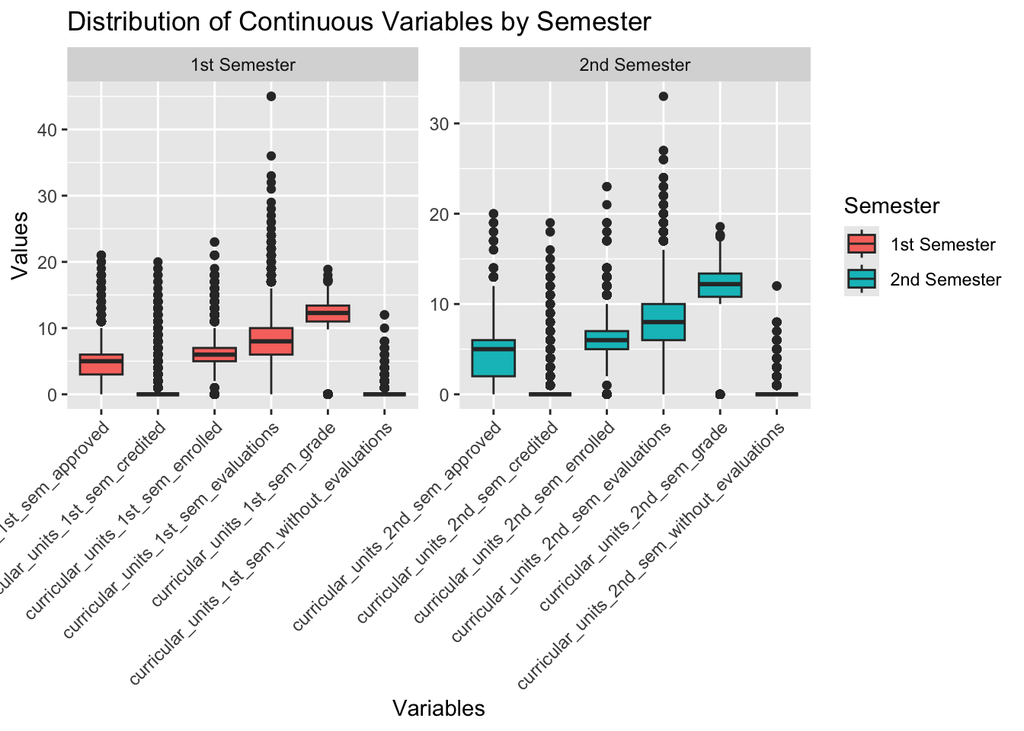

```r
# Boxplot of variables grouped by semester
units_distributed<- traindata %>%
  select(all_of(semester_variables$variable_name)) %>%
  pivot_longer(everything(), names_to = "variable_name", values_to = "value") %>%
  left_join(semester_variables, by = c("variable_name" = "variable_name")) %>%
  ggplot(aes(x = variable_name, y = value, fill = Semester)) + # Match exact case of "Semester"
  geom_boxplot() +
  facet_wrap(~ Semester, scales = "free") + # Ensure "Semester" column exists and matches case
  labs(
    title = "Distribution of Continuous Variables by Semester",
    x = "Variables",
    y = "Values",
    fill = "Semester"
  ) +
  theme(axis.text.x = element_text(angle = 45, hjust = 1))
units_distributed
```

Most clearly, students on average are earning 0 credits, which may be more descriptive of graduates who are no longer earning credits, but also telling of students who might have dropped out, more than students enrolled (which is the smallest group). Without more context into what units credited means, it’s hard to draw conclusions.

Again, average grades are only just above 10/20 in semester 1, with some more variablility in semester 2, but a similar average.

## Explore Categorical variables,

This section looks at nationality, Previous qualification (education), previous qualification (education) grade, degree programs, and courses.

### Nationality

Below shows over 97% of the dataset is Portuguese. An appropriate finding for a Portugal based university.

```r
# Summarize nationality distribution in the dataset
nationality_summary <- traindata %>%
  group_by(nacionality) %>%
  summarize(
    count = n(),
    percentage = (n() / nrow(traindata)) * 100
  ) %>%
  arrange(desc(count))
print(nationality_summary)
```

```
## # A tibble: 21 × 3
##    nacionality count percentage
##          <int> <int>      <dbl>
##  1           1  3449    97.4
##  2          41    30     0.847
##  3          26    13     0.367
##  4           6    11     0.311
##  5          22     9     0.254
##  6          24     4     0.113
##  7         100     3     0.0847
##  8         103     3     0.0847
##  9           2     2     0.0565
## 10          11     2     0.0565
## # ℹ 11 more rows
```

```r
# Pull description for nationality (row 8) in the variable table
variable_description <- variable_table %>%
  slice(8) %>%
  select(variable_name, description) %>%
  mutate(description = str_wrap(description, width = 80))
description_text <- variable_description$description
cat(description_text)
```

```
## 1 - Portuguese - 2 - German 6 - Spanish 11 - Italian 13 - Dutch 14 - English 17
## - Lithuanian 21 - Angolan 22 - Cape Verdean 24 - Guinean 25 - Mozambican 26 -
## Santomean 32 - Turkish 41 - Brazilian 62 - Romanian 100 - Moldova (Republic of)
## 101 - Mexican 103 - Ukrainian 105 - Russian 108 - Cuban 109 - Colombian
```

### Previous Educational Achievement

Result below show that 84% of students in the sample have recently come from secondary education (1) AKA High Schools suggesting the sample describes largely Freshman and Sophomore students who had not had other more recent achievements, like the 5% with Technological specialization course (39). Notably, ~4%, the third largest group, is coming with 9,10,11th grade completed, but not a secondary level degree. Suggesting these students are taking college credits while in High School. This group may perform better or worse than others and could be a useful feature.

```r
previous_education_summary <- traindata %>%
  group_by(previous_qualification) %>%
  summarize(
    Count = n(),
    Percentage = (n() / nrow(traindata)) * 100
  ) %>%
  arrange(desc(Count))
print(previous_education_summary)
```

```
## # A tibble: 16 × 3
##    previous_qualification Count Percentage
##                     <int> <int>      <dbl>
##  1                      1  2971    83.9
##  2                     39   182     5.14
##  3                     19   129     3.64
##  4                      3    94     2.66
##  5                     12    38     1.07
##  6                     40    32     0.904
##  7                     42    29     0.819
##  8                      2    20     0.565
##  9                      6    11     0.311
## 10                      9     9     0.254
## 11                      4     7     0.198
## 12                     38     6     0.169
## 13                     43     5     0.141
## 14                     10     4     0.113
## 15                     15     2     0.0565
## 16                      5     1     0.0282
```

```r
# Pull description for educational achievement (row 6) in the variable table
variable_description <- variable_table %>%
  slice(6) %>%
  select(variable_name, description) %>%
  mutate(description = str_wrap(description, width = 80))
description_text <- variable_description$description
cat(description_text)
```

```
## 1 - Secondary education 2 - Higher education - bachelor's degree 3 - Higher
## education - degree 4 - Higher education - master's 5 - Higher education -
## doctorate 6 - Frequency of higher education 9 - 12th year of schooling - not
## completed 10 - 11th year of schooling - not completed 12 - Other - 11th year
## of schooling 14 - 10th year of schooling 15 - 10th year of schooling - not
## completed 19 - Basic education 3rd cycle (9th/10th/11th year) or equiv. 38
## - Basic education 2nd cycle (6th/7th/8th year) or equiv. 39 - Technological
## specialization course 40 - Higher education - degree (1st cycle) 42 -
## Professional higher technical course 43 - Higher education - master (2nd cycle)
```

Below confirms the age of the sample is aligns with first and second year univeristy students. About half the sample is 18 or 19, with 80% falling between 18 and 27.

```r
# Summarize age_at_enrollment
age_summary <- traindata %>%
  group_by(age_at_enrollment) %>%
  summarize(
    Count = n(),
    Percentage = (n() / nrow(traindata)) * 100
  ) %>%
  arrange(desc(Percentage))
print(age_summary)
```

```
## # A tibble: 46 × 3
##    age_at_enrollment Count Percentage
##                <int> <int>      <dbl>
##  1                18   825      23.3
##  2                19   746      21.1
##  3                20   483      13.6
##  4                21   255       7.20
##  5                22   144       4.07
##  6                24   101       2.85
##  7                23    83       2.34
##  8                25    72       2.03
##  9                26    71       2.01
## 10                27    68       1.92
## # ℹ 36 more rows
```

### Previous Education Grade

The average grade coming into university was about 133/200, with a standard deviation of 13.

```r
# Summarize previous_qualification_grade (index 7)
grade_summary <- traindata %>%
  summarize(
    Min_Grade = min(previous_qualification_grade, na.rm = TRUE),
    Max_Grade = max(previous_qualification_grade, na.rm = TRUE),
    Mean_Grade = mean(previous_qualification_grade, na.rm = TRUE),
    Median_Grade = median(previous_qualification_grade, na.rm = TRUE),
    SD_Grade = sd(previous_qualification_grade, na.rm = TRUE)
  )
print(grade_summary)
```

```
##   Min_Grade Max_Grade Mean_Grade Median_Grade SD_Grade
## 1        95       190   132.6108        133.1 13.30456
```

```r
# Pull description for previous education grade (row 7) in the variable table
variable_description <- variable_table %>%
  slice(7) %>%
  select(variable_name, description) %>%
  mutate(description = str_wrap(description, width = 80))
description_text <- variable_description$description
cat(description_text)
```

```
## Grade of previous qualification (between 0 and 200)
```

### Courses

Investigating the distribution of courses [row 4] taken in the sample will contribute to understanding the study and where possible student support is need. Below shows that out of 17 courses and 3540 students, the majority (17%) are in the nursing program, 8.5% in Management, 8% in social services, and ~8% in both veterinary nursing and Journalism and communication. The rest of the course have 6% - .2% each. These results suggest a good distribution across fields of study.

```r
course_summary <- traindata %>%
  group_by(course) %>%
  summarize(
    Count = n(),
    Percentage = (n() / nrow(traindata)) * 100
  ) %>%
  arrange(desc(Percentage))
print(course_summary)
```

```
## # A tibble: 17 × 3
##    course Count Percentage
##     <int> <int>      <dbl>
##  1   9500   615     17.4
##  2   9147   299      8.45
##  3   9238   283      7.99
##  4   9085   273      7.71
##  5   9773   267      7.54
##  6   9991   222      6.27
##  7   9670   213      6.02
##  8   9254   203      5.73
##  9   9070   177      5
## 10   8014   175      4.94
## 11   9003   164      4.63
## 12    171   161      4.55
## 13   9853   151      4.27
## 14   9119   141      3.98
## 15   9130   121      3.42
## 16   9556    67      1.89
## 17     33     8      0.226
```

```r
# Sum the Count column
total_students <- course_summary %>%
  summarize(Total_Count = sum(Count))
print(total_students)
```

```
## # A tibble: 1 × 1
##   Total_Count
##         <int>
## 1        3540
```

```r
# Pull description for course (row 4) in the variable table
variable_description <- variable_table %>%
  slice(4) %>%
  select(variable_name, description) %>%
  mutate(description = str_wrap(description, width = 80))
# Print Description
description_text <- variable_description$description
cat(description_text)
```

```
## 33 - Biofuel Production Technologies 171 - Animation and Multimedia Design
## 8014 - Social Service (evening attendance) 9003 - Agronomy 9070 - Communication
## Design 9085 - Veterinary Nursing 9119 - Informatics Engineering 9130 -
## Equinculture 9147 - Management 9238 - Social Service 9254 - Tourism 9500 -
## Nursing 9556 - Oral Hygiene 9670 - Advertising and Marketing Management 9773 -
## Journalism and Communication 9853 - Basic Education 9991 - Management (evening
## attendance)
```

### Exploratory Data Analysis Summary:

Based on the insights from the exploratory analysis, the next section engineers new features. These features will capture important factors such as financial status, academic performance, and course difficulty, enhancing the predictive power of the models to be built.

## Feature Development

Feature development is the practice of getting the most out of a dataset by introducing new variables. The feature engineering function below creates 26 new features in 10 categories. The description of each category of features is found at the end of each chunk of code in the following function

```r
feature_engineering <- function(data) {

  # 1. Grading Scale Mapping (Numeric Categories)
  map_grades_to_category <- function(grade) {
    case_when(
      grade >= 18 & grade <= 20 ~ 5,  # Very Good with Distinction
      grade >= 16 & grade < 18 ~ 4,   # Very Good
      grade >= 14 & grade < 16 ~ 3,   # Good
      grade >= 10 & grade < 14 ~ 2,   # Sufficient
      grade >= 7 & grade < 10 ~ 1,    # Poor
      grade < 7 ~ 0,                  # Very Poor
      TRUE ~ NA_real_                 # Handle missing values
    )
  }
  data <- data %>%
    mutate(
      grade_category_1st_sem = map_grades_to_category(curricular_units_1st_sem_grade),
      grade_category_2nd_sem = map_grades_to_category(curricular_units_2nd_sem_grade)
    ) # The grade_categories features use the Portuguese grading standards to define 6 ordinal academic performance categories.

  # 2. Owe Money Feature
  data <- data %>%
    mutate(
      owe_money = ifelse(debtor == 1 & tuition_fees_up_to_date == 0, 1, 0)
    ) # The owe_money feature attempts to create meaning out of students who are financially strained vs. those who are not.

  # 3. Failing Features
  data <- data %>%
    mutate(
      failing_first_sem = ifelse(grade_category_1st_sem <= 1, 1, 0),
      failing_both_semesters = ifelse(grade_category_1st_sem <= 1 & grade_category_2nd_sem <= 1, 1, 0)
    ) # These failing semester features define class failure vs. pass by using the grade_category in feature #1.

  # 4. Under-Enrolled
  data <- data %>%
    mutate(
      under_enrolled_1st_sem = ifelse(curricular_units_1st_sem_enrolled < 10, 1, 0),
      under_enrolled_2nd_sem = ifelse(curricular_units_2nd_sem_enrolled < 10, 1, 0),
      under_enrolled_both_sem = ifelse(under_enrolled_1st_sem == 1 & under_enrolled_2nd_sem == 1, 1, 0)
    ) # The under-enrolled feature identifies students who are off track for graduating on time by
  # using a threshold of 50% of the required pace. To graduate in 4 years with 180 credits,
  # students need 22.5 credits per semester. This feature flags students enrolled in fewer than
  # half that amount (10 credits in the 1st semester and 2nd semester).

  # 5. Course Difficulty
  data <- data %>%
    group_by(course) %>%
    mutate(
      avg_grade_1st_sem = mean(curricular_units_1st_sem_grade, na.rm = TRUE),
      std_grade_1st_sem = sd(curricular_units_1st_sem_grade, na.rm = TRUE),
      avg_grade_2nd_sem = mean(curricular_units_2nd_sem_grade, na.rm = TRUE),
      std_grade_2nd_sem = sd(curricular_units_2nd_sem_grade, na.rm = TRUE)
    ) %>%
    ungroup() %>%
    mutate(
      overall_avg_grade = (avg_grade_1st_sem + avg_grade_2nd_sem) / 2,
      overall_std_grade = (std_grade_1st_sem + std_grade_2nd_sem) / 2
    ) # The course difficulty feature quantifies how challenging a course is based on all student grades in the sample.

  # 6. Hard Courses
  data <- data %>%
    mutate(
      hard_courses = ifelse(curricular_units_1st_sem_evaluations > 10, 1, 0)
    ) # Hard courses assume that many evaluations/tests make a course harder.

  # 7. Discouraging Courses
  data <- data %>%
    group_by(course) %>%
    mutate(
      avg_course_grade = mean(curricular_units_1st_sem_grade, na.rm = TRUE)
    ) %>%
    ungroup() %>%
    mutate(
      discouraging_courses = ifelse(avg_course_grade < 10, 1, 0)
    )# Courses with low average grades (below the passing threshold of 10) are flagged as discouraging.

  # 8. Historical Success
  data <- data %>%
    mutate(
      normalized_previous_grade = previous_qualification_grade / 200,
      strong_historical_success = ifelse(normalized_previous_grade >= 0.663, 1, 0),
      weak_historical_success = ifelse(normalized_previous_grade < 0.5966, 1, 0)
    ) # Uses normalized thresholds to categorize students with strong or weak prior success before coming to university.

  # 9. Grade-Based Summaries
  data <- data %>%
    mutate(
      average_grade = (curricular_units_1st_sem_grade + curricular_units_2nd_sem_grade) / 2,
      semester_grade_gap = curricular_units_2nd_sem_grade - curricular_units_1st_sem_grade
    ) # Summarizes overall grade performance and tracks grade changes between semesters.

  # 10. Prior Education Group Distributions
  data <- data %>%
    group_by(previous_qualification) %>%
    mutate(
      prior_avg_grade_1st_sem = mean(curricular_units_1st_sem_grade, na.rm = TRUE),
      prior_std_grade_1st_sem = sd(curricular_units_1st_sem_grade, na.rm = TRUE),
      prior_avg_grade_2nd_sem = mean(curricular_units_2nd_sem_grade, na.rm = TRUE),
      prior_std_grade_2nd_sem = sd(curricular_units_2nd_sem_grade, na.rm = TRUE)
    ) %>%
    ungroup()
  # Tracks grade patterns for students by prior education level.

  return(data)
}


# Apply to training data
traindata <- feature_engineering(traindata)
```

## Validate Feature Development on Training Data

This section validates that the feature engineering function above was effective and didn’t introduce NA’s into the dataset.

The following code prints the new size of the datasets (now 63 Features):

```r
ncol(traindata)
```

```
## [1] 63
```

```r
colnames(traindata)
```

```
##  [1] "marital_status"
##  [2] "application_mode"
##  [3] "application_order"
##  [4] "course"
##  [5] "daytime_evening_attendance"
##  [6] "previous_qualification"
##  [7] "previous_qualification_grade"
##  [8] "nacionality"
##  [9] "mother_s_qualification"
## [10] "father_s_qualification"
## [11] "mother_s_occupation"
## [12] "father_s_occupation"
## [13] "admission_grade"
## [14] "displaced"
## [15] "educational_special_needs"
```

[output cut: 48 more lines]

The following function does 4 key things to evaluate the newly engineered features: - 1. Count total NAs in the dataset - 2. Count total NAs in each feature - 3. Count if any features are 100% 0 or 1 to indicate a lack of predictive power - 4. Plots 8 of a few of the 26 new features

```r
validate_features <- function(data) {
  # 1. Count Total NAs in the Dataset
  total_na <- sum(is.na(data))
  cat("Total NA Count in Dataset:", total_na, "\n")

  # 2. Count NAs per Feature
  na_counts <- data %>%
    summarise(across(everything(), ~ sum(is.na(.)))) %>%
    pivot_longer(everything(), names_to = "Feature", values_to = "NA_Count") %>%
    arrange(desc(NA_Count))

  print("NA Counts for Each Feature:")
  print(na_counts)

  # 3. Identify Features with 100% 0s or 1s
  constant_features <- data %>%
    summarise(across(everything(), ~ all(. == 0, na.rm = TRUE) | all(. == 1, na.rm = TRUE))) %>%
    pivot_longer(everything(), names_to = "Feature", values_to = "Is_Constant") %>%
    filter(Is_Constant == TRUE)

  if (nrow(constant_features) > 0) {
    cat("Features with 100% 0s or 1s:\n")
    print(constant_features$Feature)
  } else {
    cat("No features have 100% 0s or 1s.\n")
  }

  # 4. Visualize Key Features
  key_features <- c(
    "owe_money",
    "failing_first_sem",
    "under_enrolled_2nd_sem", "under_enrolled_both_sem",
    "discouraging_courses", "weak_historical_success",
    "average_grade", "semester_grade_gap"
  )

  feature_plots <- list()
  for (feature in key_features) {
    if (feature %in% names(data)) {
      p <- ggplot(data, aes_string(x = feature)) +
        geom_bar(fill = "steelblue", color = "black") +
        labs(
          title = paste("Distribution of", feature),
          x = feature,
          y = "Count"
        ) +
        theme_minimal()
      feature_plots[[feature]] <- p
    }
  }

  # Return validation results
  return(list(
    na_counts = na_counts,
    total_na = total_na,
    constant_features = constant_features,
    feature_plots = feature_plots
  ))
}
# Apply the updated validation function
validation_train_results <- validate_features(traindata)
```

```
## Total NA Count in Dataset: 2
## [1] "NA Counts for Each Feature:"
## # A tibble: 63 × 2
##    Feature                      NA_Count
##    <chr>                           <int>
##  1 prior_std_grade_1st_sem             1
##  2 prior_std_grade_2nd_sem             1
##  3 marital_status                      0
##  4 application_mode                    0
##  5 application_order                   0
##  6 course                              0
##  7 daytime_evening_attendance          0
##  8 previous_qualification              0
##  9 previous_qualification_grade        0
## 10 nacionality                         0
## # ℹ 53 more rows
## No features have 100% 0s or 1s.
```

With the function applied, now inspect the traindata for errors.

```r
# Total NAs in the dataset
cat("Total NA Count:", validation_train_results$total_na, "\n")
```

```
## Total NA Count: 2
```

```r
# NA counts per feature
print(validation_train_results$na_counts)
```

```
## # A tibble: 63 × 2
##    Feature                      NA_Count
##    <chr>                           <int>
##  1 prior_std_grade_1st_sem             1
##  2 prior_std_grade_2nd_sem             1
##  3 marital_status                      0
##  4 application_mode                    0
##  5 application_order                   0
##  6 course                              0
##  7 daytime_evening_attendance          0
##  8 previous_qualification              0
##  9 previous_qualification_grade        0
## 10 nacionality                         0
## # ℹ 53 more rows
```

The dataset only has 2 NAs. These two instances can be removed for simplicity. Additionally, no variables appear to have no predictive power by haivng only 1s or 0s.

```r
# Count features with 100% 0s or 1s
if (nrow(validation_train_results$constant_features) > 0) {
  cat("Features with constant values (100% 0s or 1s):\n")
  print(validation_train_results$constant_features$Feature)
} else {
  cat("No features have 100% 0s or 1s.\n")
}
```

```
## No features have 100% 0s or 1s.
```

```r
traindata <- traindata %>% drop_na()
# Validate the dataset no longer contain NAs
cat("Total NA Count in Training Dataset after removal:", sum(is.na(traindata)), "\n")
```

```
## Total NA Count in Training Dataset after removal: 0
```

Below visualize several of the new features for added insight. Their breakdown is below.

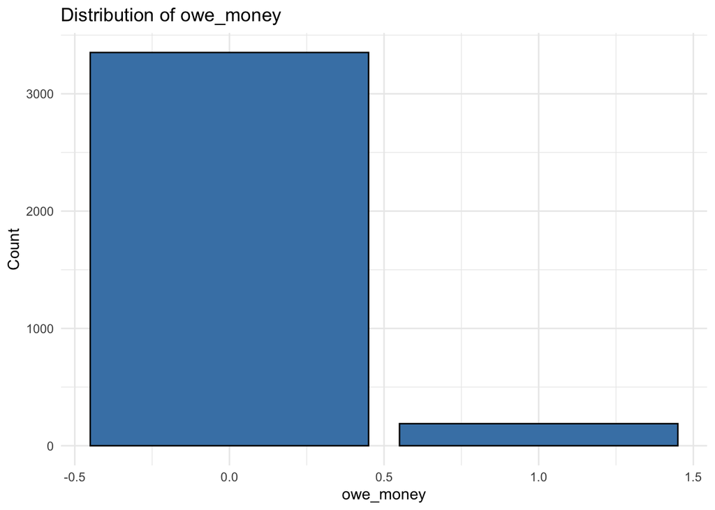

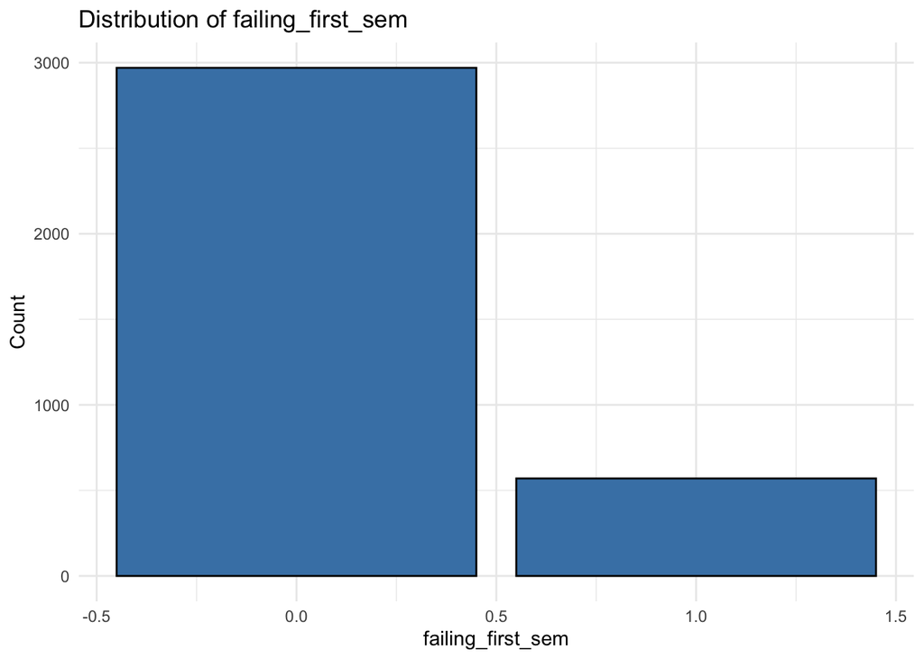

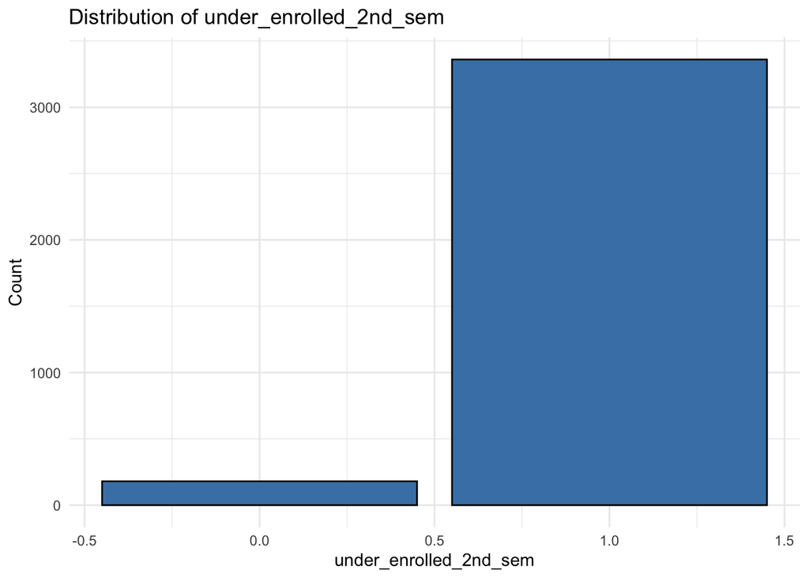

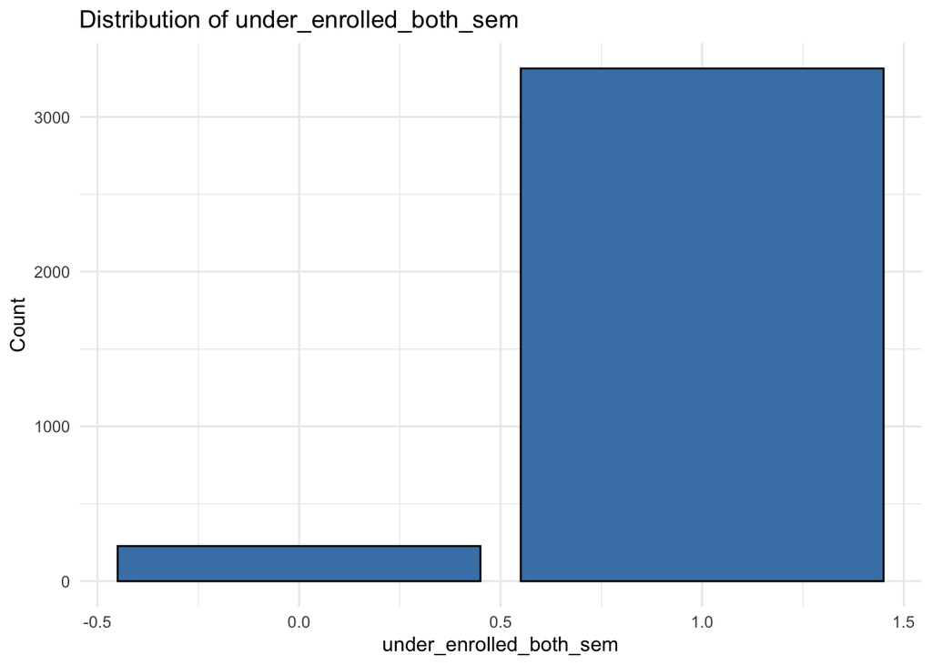

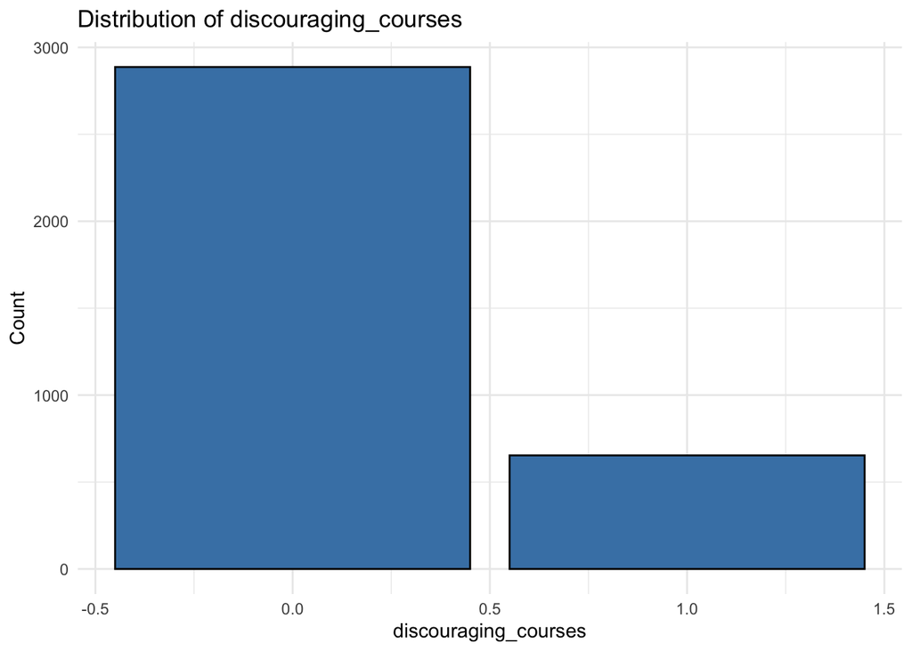

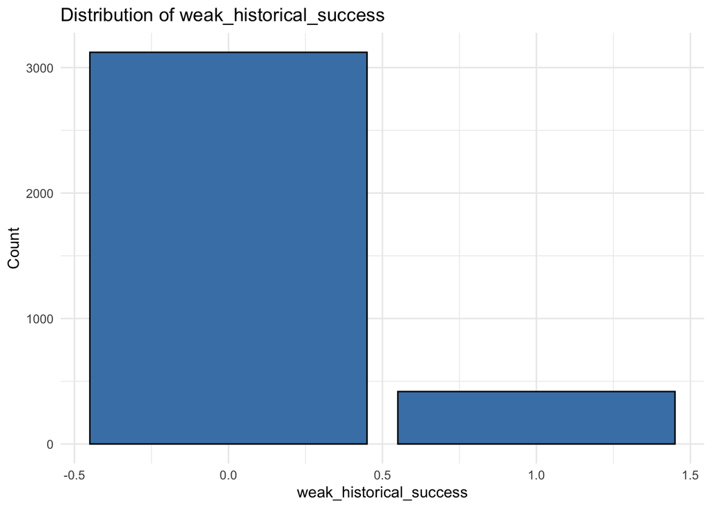

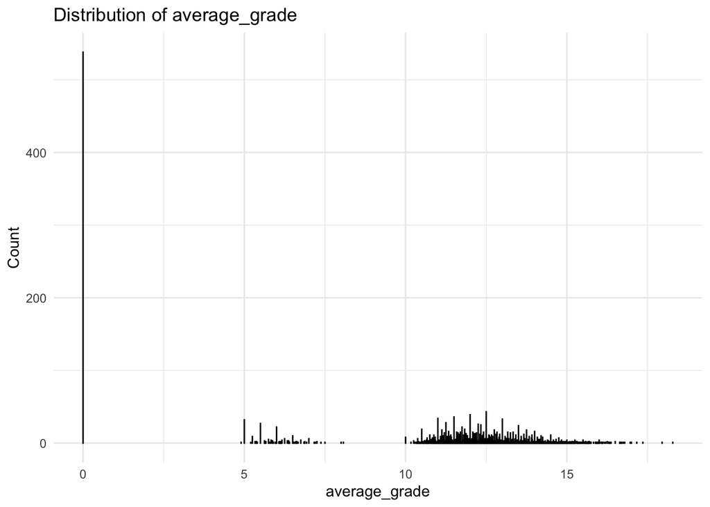

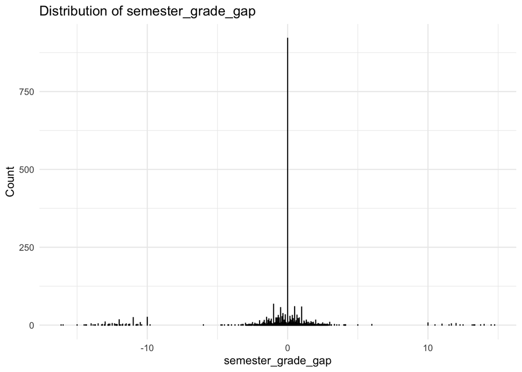

```r
# View the plots for key features
for (feature_name in names(validation_train_results$feature_plots)) {
  print(validation_train_results$feature_plots[[feature_name]])
}
```

This feature validation section shows that the number of features has been nearly doubled. This could increase predictive power, but could also increase the likelihood of over-fitting. To avoid over fitting steps will be taken in modeling, like cross validation.

## Choosing Classification

This section justifies classification as the task for predicting student outcomes.

Since the college outcomes in this dataset are categorized into three distinct groups—dropout, enrolled, and graduated—a classification approach is the most suitable modeling strategy. Classification enables the algorithm to learn from the dataset and classify each student into one of these three outcome groups based on the provided features. This approach aligns well with the structure of the target variable and ensures predictions are interpretable and actionable.

Start by splitting the dataset as before, this time for training the traindata:

```r
# Partition traindata
set.seed(456)
train_model_index <- createDataPartition(traindata$target, p = 0.8, list = FALSE)
training_set <- traindata[train_model_index, ]   #training_set
validation_set <- traindata[-train_model_index, ] # Validation_set for model eval

# Convert target to a factor in the training and evaluation sets
training_set$target <- as.factor(training_set$target)
validation_set$target <- as.factor(validation_set$target)
```

## Model #1 Decision Tree Classification

### Train the Decision Tree (DT) Model

```r
#Training
decision_tree_model <- rpart(
  target ~ .,
  data = training_set,
  method = "class"
)
```

With the model trained, now use it to predict target on the validation set.

```r
## Predict on the validation set
dt_predictions <- predict(decision_tree_model, validation_set, type = "class")

## Evaluate the model
dt_conf_matrix <- confusionMatrix(dt_predictions, validation_set$target)
print(dt_conf_matrix)
```

```
## Confusion Matrix and Statistics
##
##           Reference
## Prediction   1   2   3
##          1 186  44  17
##          2   0   0   0
##          3  43  81 336
##
## Overall Statistics
##
##                Accuracy : 0.7383
##                  95% CI : (0.7043, 0.7704)
##     No Information Rate : 0.4993
##     P-Value [Acc > NIR] : < 2.2e-16
##
##                   Kappa : 0.5344
##
##  Mcnemar's Test P-Value : < 2.2e-16
##
## Statistics by Class:
##
##                      Class: 1 Class: 2 Class: 3
## Sensitivity            0.8122   0.0000   0.9518
## Specificity            0.8724   1.0000   0.6497
## Pos Pred Value         0.7530      NaN   0.7304
## Neg Pred Value         0.9065   0.8232   0.9312
## Prevalence             0.3239   0.1768   0.4993
## Detection Rate         0.2631   0.0000   0.4752
## Detection Prevalence   0.3494   0.0000   0.6506
## Balanced Accuracy      0.8423   0.5000   0.8008
```

The model performs well in predicting students who will drop out and graduate: - **81% of actual dropouts were correctly identified as dropouts (Sensitivity = 0.8122).** - **73% of predicted graduates were correct (Positive Predictive Value = 0.7304).**

However, there are notable challenges: - The model entirely fails to predict the “enrolled” class (Sensitivity = 0, Precision = NaN). This suggests a lack of information or patterns in the data for this group or is the impact of class imbalance (as seen below)

```r
table(training_set$target)
```

```
##
##    1    2    3
##  895  522 1415
```

- A concerning mis-classification occurs where **43 students who dropped out were classified as graduates.
- This is problematic because mis-classifying a dropout as a graduate could lead to overlooking at-risk students needing intervention.

## Visualize the Decision Tree

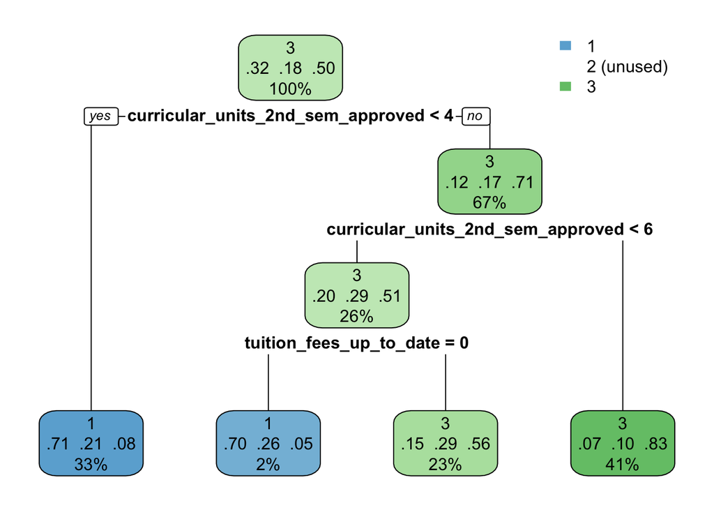

```r
rpart.plot(decision_tree_model, type = 2, extra = 104)
```

As seen in the decision tree, the model used two key variables to make it’s classifications: - curricular_units_2nd_sem_approved - tuition_fees_up_to_date. These splits effectively separated dropouts (Class 1) and graduates (Class 3) but struggled to distinctly classify enrolled (Class 2) students, as evidenced by low proportions of Class 2 in terminal nodes. Unfortunately, this means the model decided the rest of the features were not helpful. This is called overfitting when the model assumes the other variables are just noise and not worth listening to.

Practically, this finding tells counselors to focus on students who are not approved for at least 4 credits in their second semester, and who do not have their tuition fees up to date as these students are most likely to be dropout.

## Model #2: Gradient Boosted Trees with Cross-Validation

In order to account for the class imbalance, boosted trees increase the number of iterations and samplings for enrolled AKA Target =2. Additionally, to account for the many features, this model uses cross validation as the method.

```r
## Define training control for cross-validation
train_control_gbt <- trainControl(
  method = "cv",          # k-fold cross-validation
  number = 5,             # folds
  verboseIter = TRUE
)

## Define the grid of hyperparameters to tune
gbt_grid <- expand.grid(
  n.trees = seq(100, 700, by = 100),  # Number of boosting iterations
  interaction.depth = c(1, 2, 3),     # Max depth of each tree
  shrinkage = c(0.05, 0.075, 0.1),    # Learning rate
  n.minobsinnode = c(5, 10)           # Minimum number of observations in a node
)
```

With the parameters and controls set for the Gradient Boosted Trees (GBT) Model, the following food trains the model by searching for the best parameters within the ranges set above.

```r
# Train the Gradient Boosted Trees model
set.seed(123)
gbt_model <- train(
  target ~ .,
  data = training_set,
  method = "gbm",
  trControl = train_control_gbt,
  tuneGrid = gbt_grid,
  verbose = FALSE
)
```

Thanks to cross validations 5 folds, the model is trained on 4 folds and validated on the 5th. This ensures that all data is used for both training and validation. Boosting re-weights categories that are mis-classified within the folds to handle class imbalance (e.g., Target = 2)

The following code prints what the trained model above found to be optimal

```r
# Print the best model parameters from cross-validation
cat("Best Model Parameters from Cross-Validation:\n")
```

```
## Best Model Parameters from Cross-Validation:
```

```r
print(gbt_model$bestTune)
```

```
##    n.trees interaction.depth shrinkage n.minobsinnode
## 66     300                 2     0.075             10
```

With the best parameters identified, the predict function below from the caret package will automatically take these parameters and apply them to the dataset we choose. In this case, below the parameters are applied to the validation set that was created from the traindata.

```r
## Predict on the validation set
gbt_predictions <- predict(gbt_model, validation_set)

## Evaluate the model
gbt_conf_matrix <- confusionMatrix(gbt_predictions, validation_set$target)
print(gbt_conf_matrix)
```

```
## Confusion Matrix and Statistics
##
##           Reference
## Prediction   1   2   3
##          1 173  23  14
##          2  30  52  14
##          3  26  50 325
##
## Overall Statistics
##
##                Accuracy : 0.7779
##                  95% CI : (0.7455, 0.8081)
##     No Information Rate : 0.4993
##     P-Value [Acc > NIR] : < 2.2e-16
##
##                   Kappa : 0.6278
##
##  Mcnemar's Test P-Value : 1.721e-05
##
## Statistics by Class:
##
##                      Class: 1 Class: 2 Class: 3
## Sensitivity            0.7555  0.41600   0.9207
## Specificity            0.9226  0.92440   0.7853
## Pos Pred Value         0.8238  0.54167   0.8105
## Neg Pred Value         0.8873  0.88052   0.9085
## Prevalence             0.3239  0.17680   0.4993
## Detection Rate         0.2447  0.07355   0.4597
## Detection Prevalence   0.2970  0.13579   0.5672
## Balanced Accuracy      0.8390  0.67020   0.8530
```